# MECH476: Engineering Data Analysis in R

Chapter 6 Homework: Strings, Dates, and Tidying

Daniel Pelphrey

19 October, 2023

# Chapter 6 Homework

For this homework assignment, you will use data from Twitter that include tweets (2011 to 2017) from Colorado senators, which can be downloaded from Canvas. Just FYI—some tweets were cut off before Twitter’s character limit; just work with the data you have. The original data are from [FiveThirtyEight](https://github.com/fivethirtyeight/data/tree/master/twitter-ratio).

When a question asks you to make a plot, remember to set a theme, title, subtitle, labels, colors, etc. It is up to you how to personalize your plots, but put in some effort and think about making the plotting approach consistent throughout the document. For example, you could use the same theme for all plots. I also like to use the subtitle as a place for the main summary for the viewer.

## Question 1: Hashtags

Within a pipeline using the Colorado-only tweet data, select `text` variable and use `stringr::str_extract_all()` with a pattern of `"#(\\d|\\w)+"` to extract all of the hashtags from the tweets. This will return a list with one element. How many hashtags were used by Colorado senators?

```
## [1] 5436
```

## Question 2:

Colorado is on fire right now and has experienced many wildfires over the years. Let’s examine senators’ tweet activity related to wildfires based on hashtags. Using the character vector of hashtags you extracted in Question 1, search for the hashtags that include “fire” or “wildfire”. How many hashtags included “fire”? How many included “wildfire”?

```
## [1] 16
```

```
## [1] 8
```

**fire was tagged 16 times and wildfire was tagged 8 times.

## Question 3: Wildfires

Now, let’s look at general tweets concerning wildfires. First, subset the data to a dataframe that includes tweets containing the word “wildfire” and their corresponding timestamp and user. Specifically, (a) select `text`, `date`, and `user` and (b) filter to text strings that include the word “wildfire” using `dplyr::filter()` and `stringr::str_detect()`.

```
## # A tibble: 33 × 3
##    text                                                         created_at user
##    <chr>                                                        <chr>      <chr>
##  1 "Intro'd bill to help #wildfire recovery &amp; prevention e… 10/6/2017… SenB…
##  2 "Tune in to watch @USDA @forestservice briefing on fixing #… 9/26/2017… SenB…
##  3 "As #opioid addiction rips through Colorado &amp; the count… 7/5/2017 … SenB…
##  4 "Our thoughts and sympathies are with all of the families a… 7/12/2016… SenB…
##  5 "Glad to see our wildfire mitigation provision, the Good Ne… 8/6/2015 … SenB…
##  6 "#TBT to speaking with the brave firefighters from @forests… 6/11/2015… SenB…
##  7 "CO already experiencing climate change - wildfire, drought… 6/2/2014 … SenB…
##  8 "RT @WildernessNow: Great work by @SenBennetCO on linking d… 11/6/2013… SenB…
##  9 "Time to work in Congress and with @forestservice to invest… 11/5/2013… SenB…
## 10 "RT @SenateAg: Since 1980, wildfires have caused over $28 b… 11/5/2013… SenB…
## # ℹ 23 more rows
```

## Question 4: Senators

Which Colorado senator tweets more about wildfires?

```
## # A tibble: 2 × 2
## # Groups:   user [2]
##   user               n
##   <chr>          <int>
## 1 SenBennetCO       20
## 2 SenCoryGardner    13
```

** SenBennetCO had the most

## Question 5: Timing

Using the same `wildfires` dataframe, create a summary table that shows the number of tweets containing the word “wildfire” by year (2011-2017). Which year has the most tweets about wildfires? Why might this be the case? (Hint: Think about what happened in the previous year.)

```
## # A tibble: 7 × 2
## # Groups:   year [7]
##    year     n
##   <dbl> <int>
## 1  2011     2
## 2  2012     3
## 3  2013    13
## 4  2014     1
## 5  2015     6
## 6  2016     5
## 7  2017     3
```

**The most wildfire mentions occured in 2013, this was likely either because these were in reference to active wildfires this year, or recovery from a wildfire in the previous year.

## Question 6: Monthly tweets

Create a bar chart that answers the question: Are Colorado senators more active at a certain time of year? Hints: Convert `month` to a factor. Fill by `user`.

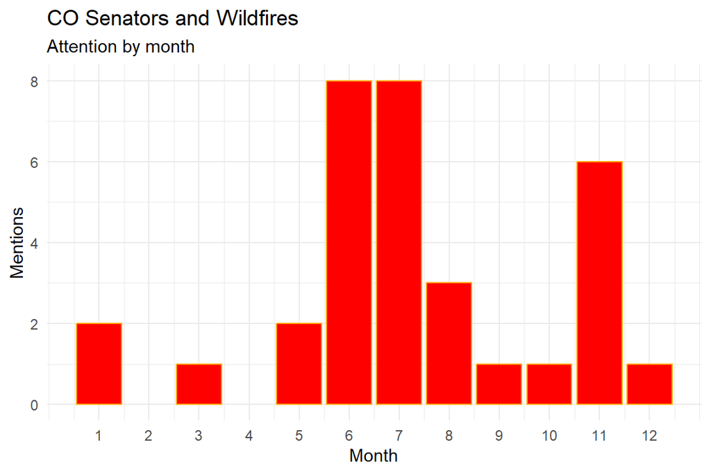

## Question 7: Hourly tweets

Create a histogram of tweets by hour of day to visualize when our senators are tweeting.

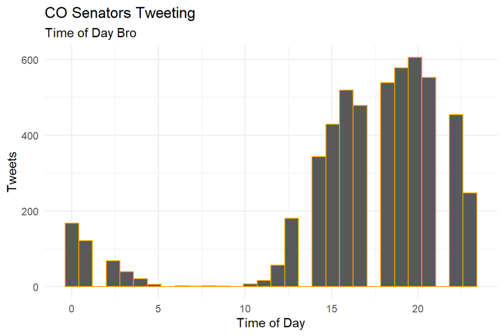

# Appendix

```r
# set global options for figures, code, warnings, and messages
knitr::opts_chunk$set(fig.width=6, fig.height=4, fig.path="../figs/",
                      echo=FALSE, warning=FALSE, message=FALSE)
library("tidyverse")
library("readr")
library("dplyr")
library("magrittr")
library("ggplot2")
library("stringr")

# wildfire hashtag list
twitter_data <-  tibble(readr::read_csv(file ="../data/senators_co.csv"))
tweets <- twitter_data$text
hashtags <- stringr::str_extract_all(tweets, "#(\\d|\\w)+")
print(length(hashtags))
invisible(unlist(hashtags))
fire_hashtags <- stringr::str_subset(hashtags, "fire")
print(length(fire_hashtags))

wildfire_hashtags <- stringr::str_subset(hashtags, "wildfire")
print(length(wildfire_hashtags))

# filter to tweets concerning wildfires

wildfire_tweets <- tibble(readr::read_csv(file ="../data/senators_co.csv")) %>%
  dplyr::select(text, created_at, user)%>%
  dplyr::filter(stringr::str_detect(text, "wildfire"))
print(wildfire_tweets)
# number of wildfire tweets by senator
senators <- wildfire_tweets %>%
  group_by(user)%>%
  count()%>%
  print()

# number of wildfire tweets by year
years <- wildfire_tweets %>%
  mutate(date = mdy_hm(created_at),
                year = year(date)) %>%
  group_by(year) %>%
  count()%>%
  print()
# create plot of tweets by month and user
custom_ticks <- c(1, 2, 3, 4, 5, 6, 7, 8, 9, 10, 11, 12)
month_data <- wildfire_tweets %>%
     mutate(date = mdy_hm(created_at),
            month = month(date)) %>%
            group_by(month)

month_chart <- ggplot(month_data) +
  geom_bar(aes(x = month),
                color = "orange",
                fill = 'red') +
  labs(x = "Month",
       y = "Mentions",
       title = "CO Senators and Wildfires",
       subtitle = "Attention by month") +
scale_x_continuous(breaks = custom_ticks) +
theme_minimal()

print(month_chart)
# create plot of cumulative hourly tweets by senator
time_data <- twitter_data %>%
     mutate(date = mdy_hm(created_at),
            hour = hour(date)) %>%
            group_by(hour)

time_chart <- ggplot(time_data) +
  geom_histogram(aes(x = hour),
                color = "orange") +
  labs(x = "Time of Day",
       y = "Tweets",
       title = "CO Senators Tweeting",
       subtitle = "Time of Day Bro") +
theme_minimal()

print(time_chart)
```